# Chimpanzees Analysis

Jessi Kehe

This R Markdown document was adapted from documents created by Professor Bret Larget.

### Setup details

- You will need the packages `tidyverse` for these lectures.
- This assumes you have the R script `viridis.R` two steps back from the working directory (`"../../scripts/viridis.R"`). Be sure to adjust the code if you have this script in a different location.
- The following data files will be used and are assumed to be located two steps back from the working directory in a folder called `data/`. Be sure to adjust the code if you have the data files in a different location.  
  `"../../data/chimpanzee.csv"`

# Lecture: Chimpanzee Data Introduction

## Case Study

- Chimpanzees were studied in a pro-social choice experiment.
  - Chimpanzees are given a sequence of choices about which color token to select.
  - One color (labeled selfish) results in them getting food.
  - Another (labeled pro-social) results in both them and a partner chimp receiving food.
  - In a control setting, there is no partner
    - different color choices result in the researcher mimicking the same actions as when partner is present (i.e., always giving the actor chimp food, making a motion with food toward the empty room for the partner chimp).
- We will develop a statistical model for this experiment.
- Each part of the experiment includes a series of 30 trials where one of two outcomes is possible.

## Inference questions

- How often does the actor chimpanzee make the pro-social choice? How much uncertainty is there in this estimate? How confident can we be that the long-run probability of making the pro-social choice in repeated trials falls within some interval?
- Do chimps make the pro-social choice more than 50 percent of the time, or is the pro-social choice made at random?
- Does the frequency with which the chimpanzee makes the pro-social choice depend on there being a partner chimpanzee in the neighboring room?

## Partial Data

- One chimpanzee (subject A) was tested 90 times with a partner (three sets of 30 trials with each of three different partners)
- The chimpanzee made the pro-social choice 60 times out of 90 trials.

## A Statistical Model

1. Name and define variables
2. Make assumptions (these can be examined later)
3. Write a probability model for the variables and required parameters
- $X$ is the number of pro-social choices that subject A makes in 90 trials.
- Assume:
  - each trial could be pro-social or selfish
  - 90 trials was predetermined
  - trials are independent (this assumption is debatable)
  - same probability of pro-social choice for each trial (this assumption is debatable)
- Under these assumptions, $X$ has a binomial distribution.
- Parameters are:
  - $n$, the number of trials. Here $n=90$.
  - $p$, an unknown long-run probability that this chimpanzee makes the pro-social choice. (We may be interesting in inference on this parameter using the data.)

The model is:

$$X \mid p \sim \text{Binomial}(n,p)$$

The data are:

- $n=90$
- $x=60$

## Point Estimates

- A *point estimate* is a statistic calculated from the data to estimate a parameter.
- We often put a “hat” over the parameter symbol to indicate an estimate.
- A natural estimate here is:
  - $\hat{p} = \frac{60}{90} = 0.667$

## Standard Error

- How accurate is this estimate?
- The (random) *estimator* is $\hat{P} = \frac{X}{n}$, where $X \sim \text{Binomial}(n,p)$  
  (I am going to use $\hat{P}$ to represent our random estimator, and $\hat{p}$ to represent the non-random observed statistic)
  - The (non-random) *estimate* is our $\hat{p} = \frac{60}{90}$
  - The variance of $\frac{X}{n}$ is $\frac{Var(X)}{n^2} = \frac{np(1-p)}{n} = \frac{p(1-p)}{n}$
- Consider the *sampling distribution* of the estimator when doing inference.
  - You can think of the sampling distribution as the distribution of all possible values of the statistic taken with a fixed sample size $n$.

$$\text{SE}(\hat{p}) = \sqrt{ \frac{p(1-p)}{n} }$$

```r
X <- 60
n <- 90
p_hat <- round(60/90,3)
p_hat
```

```
## [1] 0.667
```

```r
## Possible estimate for the SE
round(sqrt(p_hat*(1-p_hat)/n),3)
```

```
## [1] 0.05
```

# Lecture: Introduction to Confidence Intervals for p

- A confidence interval incorporates uncertainty with the point estimate to form an *interval estimate* with an attached level of confidence.
- A conventional choice is 95%, but other confidence levels are possible.
- When the sampling distribution of a point estimate is approximately normal, we typically construct confidence intervals as

$$\text{point estimate} \pm \text{margin of error}$$
where the margin of error is a critical value from a standard normal distribution multiplied by a standard error.

$$\text{margon of error} = z \times \text{SE}$$
where $z$ is selected so that the area between $-z$ and $z$ under a standard normal density matches the desired confidence level.

## Logic of Confidence Intervals

- Recall that $\hat{P} = \frac{X}{n}$ where $X \sim \text{Binomial}(n,p)$.
  - We learned previously that under certain assumptions, a binomial distribution approximately follows a normal distribution with mean $\mu = np$ and $\sigma = \sqrt{np(1-p)}$
  - This implies that our estimator $\hat{P} \sim N\left(p, \sqrt{\frac{p(1-p)}{n}}\right)$ (this is before we observe our sample so it is still random)
- If $p$ was known, then there is about a 95% chance that an observed $\hat{p}$ will be within 1.96 standard errors of $p$, assuming approximate normality.
  - This is because if $p$ is known, then $P(p-1.96 SE < \hat{P} < p + 1.96 SE) \approx 0.95$, where $SE = \sqrt{\frac{p(1-p)}{n}}$, and $\hat{p}$ is a realization of $\hat{P}$.
  - Use a different value instead of $z=1.96$ for a different confidence level.
- If we do not know $p$, but observe $\hat{p}$, there was a 95% chance before the random sample was taken that $\hat{p}$ would be within 1.96 SEs of this unknown $p$, so we can be *95% confident* that the observed $\hat{p}$ is one of the 95% of the possible ones that is within 1.96 SEs of $p$.
- Therefore, we are 95% confident that $p$ is within 1.96 SEs of $\hat{p}$.
- We construct a 95% confidence interval by forming an interval centered at a point estimate plus or minus 1.96 times the standard error.

# Lecture: Interpretation of confidence intervals

> What do we hope to capture within a confidence interval?

The unknown parameter $p$. In practice, we do not know if $p$ is or is not within the interval.

> What happens to confidence intervals when the confidence level changes?

Intuitively, to be more confident the true $p$ is captured, it makes sense that would correspond with a wider interval (all else equal)

Recall the margin of error gives the half-width of the interval:
$$\text{margon of error} = z \times \text{SE}$$

For a given SE, $z$ controls the the width of the interval. A larger $z$ results in a wider interval. Let’s review the $z$’s for a few different confidence levels.

Notice as we decrease the confidence level, the magnitude of $z$ decreases as well.

```r
qnorm((1-.95)/2) # 95%
```

```
## [1] -1.959964
```

```r
qnorm((1-.90)/2) # 90%
```

```
## [1] -1.644854
```

```r
qnorm((1-.80)/2) # 80%
```

```
## [1] -1.281552
```

> Suppose our point estimate for $p$ is $\hat{p} = .55$ and the SE($\hat{p}$) = .10. If a confidence interval is given as $[.3855, .7145]$, what confidence level was used to define this interval?

```r
p_hat <- .55
se_p <- .10
a <- .3855
b <- .7145

## Find margin of error for interval
(me <- p_hat - a)
```

```
## [1] 0.1645
```

```r
## Find the standard normal quantile:  me = z*se
(z <- me/se_p)
```

```
## [1] 1.645
```

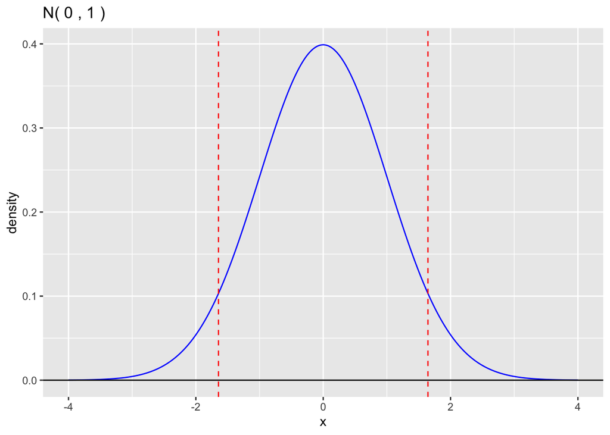

```r
gnorm(mu=0,sigma=1,a=-4,b=4) +
  geom_vline(aes(xintercept=z),color="red",linetype="dashed") +
  geom_vline(aes(xintercept=-z),color="red",linetype="dashed")
```

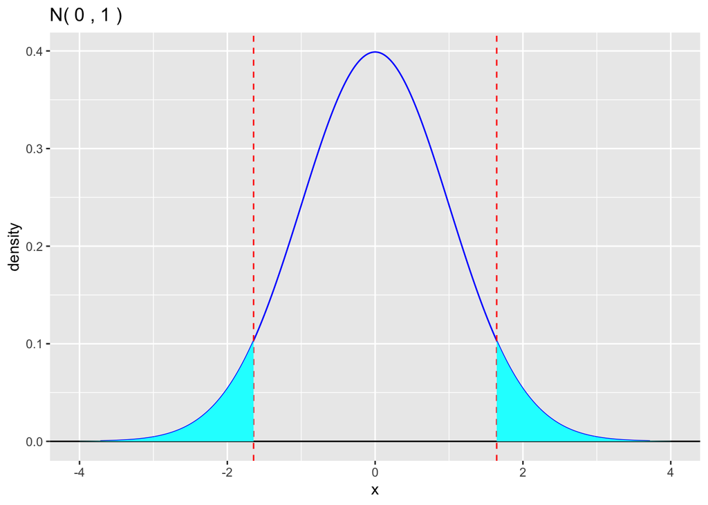

```r
## Find the tail probability
gnorm(mu=0,sigma=1) +
  geom_vline(aes(xintercept=z),color="red",linetype="dashed") +
  geom_vline(aes(xintercept=-z),color="red",linetype="dashed") +
  geom_norm_fill(a=-4,b=-z,fill="cyan") +
  geom_norm_fill(a=z,b=4,fill="cyan")
```

```r
1 - pnorm(z) + pnorm(-z) # tail probability
```

```
## [1] 0.09996981
```

```r
2*pnorm(-z)  # by symmetry of the normal density curve
```

```
## [1] 0.09996981
```

```r
## Hence, the confidence level is
1 - 2*pnorm(-z)
```

```
## [1] 0.9000302
```

```r
pnorm(z) - pnorm(-z)
```

```
## [1] 0.9000302
```

# Lecture: More on Confidence Intervals for p

## Complications

There are some complications with our confidence intervals for p:

- The standard error is $\text{SE}(\hat{p}) = \sqrt{ \frac{p(1-p)}{n} }$ which also needs to be estimated as we do not know $p$.
- The binomial distribution is discrete, and so the sampling distribution of $\hat{p}$ is also discrete and not exactly normal.

Both of these complications can lead to inaccuracies in the confidence interval approach.

We will examine this with simulation in a future lecture.

## Wald Method

- The Wald method uses the observed relative frequency as the point estimate for $p$:

$$\hat{p} \pm 1.96 \sqrt{ \frac{\hat{p}(1-\hat{p})}{n} }$$

For our observed data, we get

```r
binom_se <-  function(n,p)
{
  return ( sqrt( p*(1-p)/n) )
}

binom_ci <- function(est,se,conf)
{
  z <- qnorm(1 - (1 - conf)/2)
  me <- z * se
  ci <- est + c(-1,1)*me
  return(ci)
}

x <- 60
n <- 90
p_hat <- x/n

se_wald = binom_se(n,p_hat)

se_wald
```

```
## [1] 0.0496904
```

```r
ci_wald <- binom_ci(p_hat,se_wald,0.95)

ci_wald
```

```
## [1] 0.5692753 0.7640581
```

## Agresti-Coull Method

- The Agresti-Coull method uses a different point estimate and standard error.
- Rather using $\hat{p} = \frac{x}{n}$:
  - Act as if there were four additional observations, two successes and two failures in the sample.
  - $\tilde{p} = \frac{x+2}{n+4}$
  - This is an example of a *shrinkage* estimate, which pulls the observed proportion a bit toward 0.5.
  - Then use the modified point estimate and sample size to estimate the standard error and confidence interval.

$$\tilde{p} \pm 1.96 \sqrt{ \frac{\tilde{p}(1-\tilde{p})}{n+4} }$$

```r
x <- 60
n <- 90

p_tilde <- (x+2)/(n+4)
p_tilde
```

```
## [1] 0.6595745
```

```r
se_agresti <- binom_se(n+4,p_tilde)
se_agresti
```

```
## [1] 0.04887413
```

```r
ci_agresti <- binom_ci(p_tilde,se_agresti,0.95)
ci_agresti
```

```
## [1] 0.5637829 0.7553660
```

Theory suggests that for most values of $p$ and $n$, this approach will be more accurate.

# Lecture: Evaluating the accuracy of Confidence Intervals for p

Let’s generate a realization from a binomial distribution with $n=90$. In practice we do not know what the value for $p$ is…this is why we want to do inference on it! However, we are going to specify a value for $p$, and then pretend we don’t know it.

```r
set.seed(123)

## Generate data
n <- 90
p <- 0.25
x <- rbinom(1, n, p)
x
```

```
## [1] 20
```

```r
## Compute our point estimates
p_hat <- x/n
p_hat
```

```
## [1] 0.2222222
```

```r
p_tilde <- (x+2)/(n+4)
p_tilde
```

```
## [1] 0.2340426
```

Now let’s get our confidence intervals.

```r
se_wald <- binom_se(n,p_hat)
se_wald
```

```
## [1] 0.04382281
```

```r
ci_wald <- binom_ci(p_hat,se_wald,0.95)

se_agresti <- binom_se(n+4,p_tilde)
se_agresti
```

```
## [1] 0.04367026
```

```r
ci_agresti <- binom_ci(p_tilde,se_agresti,0.95)

rbind(ci_wald, ci_agresti)
```

```
##                 [,1]      [,2]
## ci_wald    0.1363311 0.3081134
## ci_agresti 0.1484504 0.3196347
```

Since we know the true value of $p$ (we selected it), we can check if our intervals captured the true $p$.  
Both intervals captured our $p$. Yay! Does this always happen?

We can check the accuracy of the intervals, more specifically the *capture probability* (aka coverage probability). This is the long-run performance of the intervals if we repeatedly drew samples of the same size from the same population. Ideally this would match the confidence level (e.g., 95%).

In the next chunk, we will do the same thing as above, but a bunch more times. Also, we will focus on the Wald intervals here, but you can repeat this exercise for the Agresti-Coull method on your own.

```r
set.seed(123)
n <- 90
p <- 0.25
N <- 1000 # Number of repetitions
captured_p <- rep(NA,N)
for(i in 1:N){
  x <- rbinom(1, n, p)
  p_hat <- x/n
  se_wald <- binom_se(n,p_hat)
  a_wald <- p_hat - qnorm(0.975)*se_wald
  b_wald <- p_hat + qnorm(0.975)*se_wald
  captured_p[i] <- ifelse(a_wald<=p & b_wald>=p, 1, 0)
}

## How many intervals captured our p?
sum(captured_p)
```

```
## [1] 946
```

```r
## What's our estimate for the capture probability?
mean(captured_p)
```

```
## [1] 0.946
```

```r
## Try running the above code a few more times (be sure to avoid the set.seed() command or you will keep getting the same answer)
## Try changing the value of N
```

We’ll do more simulations in other lectures to evaluate and compare the performance of our confidence intervals.

# Lecture: Confidence Interval Simulation Study

## Explore Confidence Intervals by Simulation

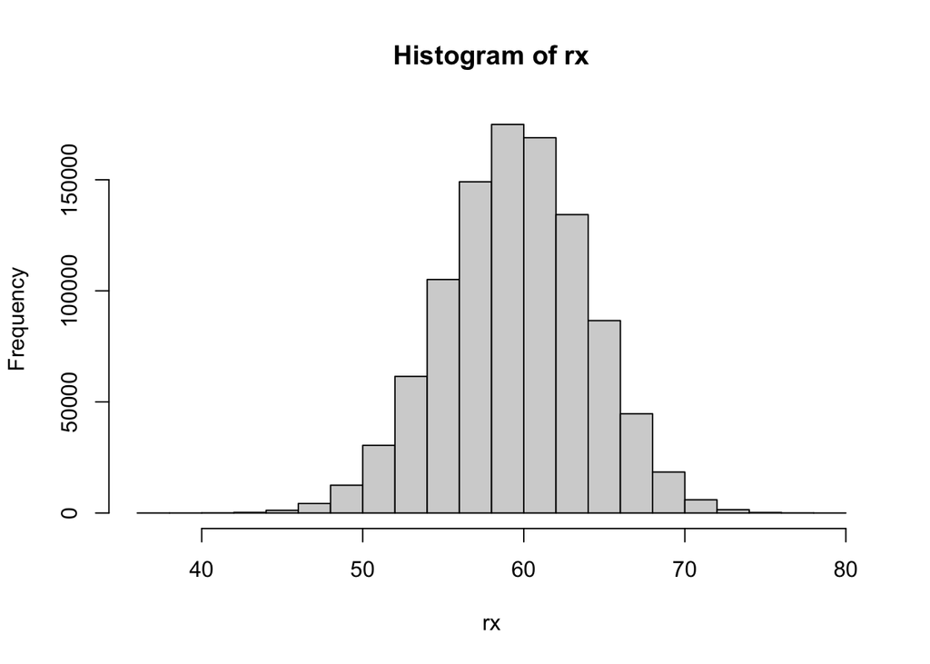

```r
set.seed(96573)
N <- 1000000 # Number of repetitions
p <- 2/3
n <- 90
rx <- rbinom(N,n,p) # Large sample of Binomial(n,p) random variables

hist(rx)
```

```r
## Consider all the possible observed values for X
## Calculate confidence intervals using the Wald and Agresti-Coull Methods
df <- tibble(
  n = rep(90,91),
  x = 0:90,
  p_hat = x/n,
  p_tilde = (x+2)/(n+4),
  se_wald = binom_se(n,p_hat),
  se_agresti = binom_se(n+4,p_tilde),
  a_wald = p_hat - qnorm(0.975)*se_wald,
  b_wald = p_hat + qnorm(0.975)*se_wald,
  a_agresti = p_tilde - qnorm(0.975)*se_agresti,
  b_agresti = p_tilde + qnorm(0.975)*se_agresti
)

## Find the range of Wald intervals that would capture our p = 2/3
df_wald <- df %>%
  filter(a_wald <= p & p <= b_wald) %>%
  summarize(minx = min(x), maxx = max(x))

## Estimated Wald coverage probability
mean(rx >= df_wald$minx & rx <= df_wald$maxx)
```

```
## [1] 0.937515
```

```r
## Find the range of Agresti-Coull intervals that would capture our p = 2/3
df_agresti <- df %>%
  filter(a_agresti <= p & p <= b_agresti) %>%
  summarize(minx = min(x), maxx = max(x))

## Estimated Agresti-Coull coverage probability
mean(rx >= df_agresti$minx & rx <= df_agresti$maxx)
```

```
## [1] 0.943096
```

## Observations

- For the size of the simulation, we expect to match the true capture probability to within about 2.2^{-4}.
- For $n=90$ and $p=2/3$, neither method matches the exact 95% capture probability.
- It would be interesting to repeat this calculations for different values of $p$ for $n=90$ (and then again for other $n$).

## Direct calculations

Rather than simulating a large number of binomial random variables to calculate the coverage probability of the confidence intervals, we can directly calculate the coverage probabilities.

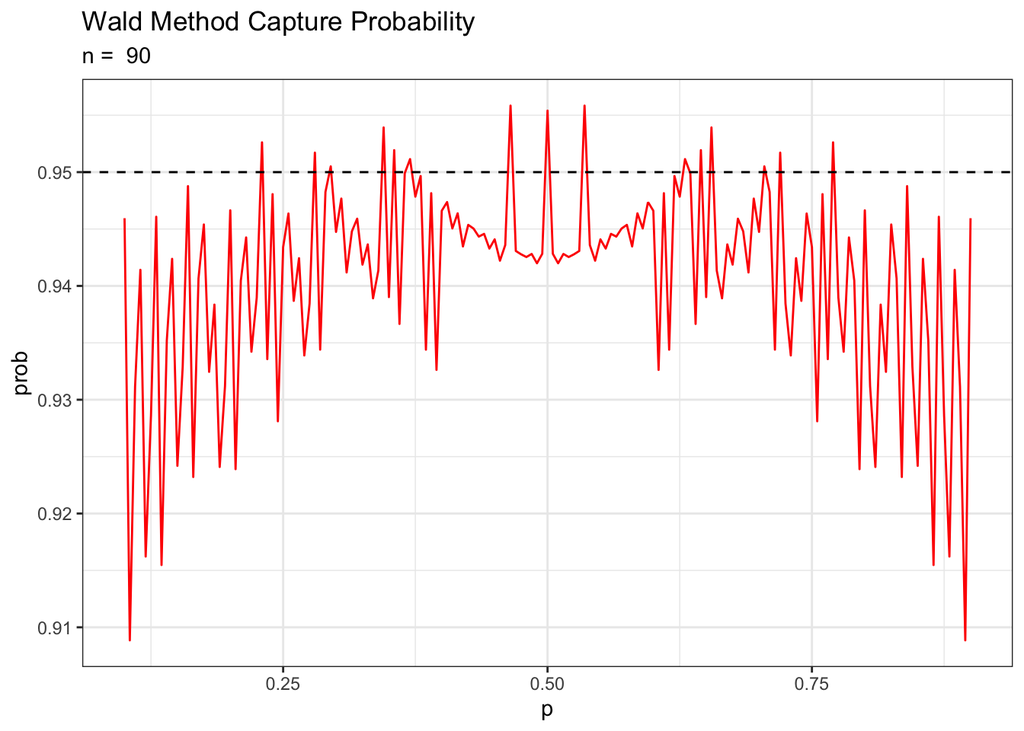

```r
## Calculate the coverage probability
calc_wald <- function(n,p,conf=0.95)
{
  z <- qnorm(1 - (1-conf)/2)
  df <- tibble(
    x = 0:n,
    d = dbinom(x,n,p), # we use dbinom instead of simulating with rbinom
    p_hat = x/n,
    se = sqrt( p_hat*(1-p_hat)/n ),
    a = p_hat - z*se,
    b = p_hat + z*se)
  prob <- df %>%
    filter(a < p & p < b) %>%
    summarize(prob = sum(d)) %>%
    pull(prob)
  return ( prob )
}

capture_wald <- function(n,seq_p,conf=0.95)
{
  prob <- numeric(length(seq_p))
  for ( i in 1:length(seq_p))
    prob[i] <- calc_wald(n,seq_p[i],conf)
    df <- tibble(p = seq_p,prob=prob)
  return ( df )
}

plot_wald <- function(n,seq_p,conf=0.95,...)
{
  capture_wald(90,seq(0.1,0.9,0.005)) %>%
  ggplot(aes(x=p,y=prob)) +
    geom_line(...) +
    geom_hline(yintercept = conf, linetype = "dashed") +
    ggtitle("Wald Method Capture Probability",
            subtitle = paste("n = ",n)) +
    theme_bw()
}

plot_wald(90,seq(0.1,0.9,length.out=501),conf=0.95,color="red")
```

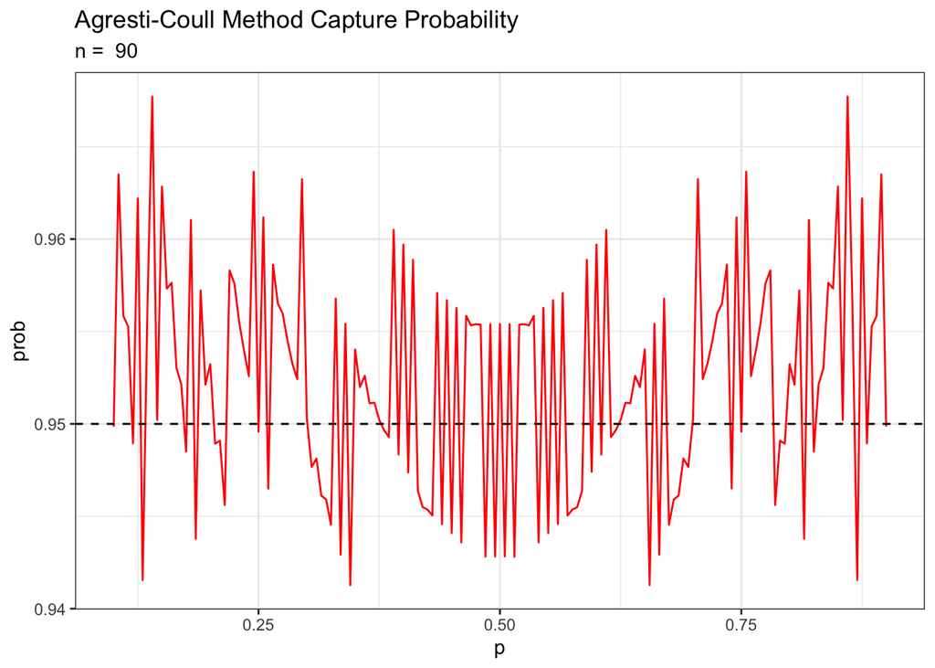

```r
calc_agresti <- function(n,p,conf=0.95)
{
  z <- qnorm(1 - (1-conf)/2)
  df <- tibble(
    x = 0:n,
    d = dbinom(x,n,p),
    p_tilde = (x+2)/(n+4),
    se = sqrt( p_tilde*(1-p_tilde)/(n+4) ),
    a = p_tilde - z*se,
    b = p_tilde + z*se)
  prob <- df %>%
    filter(a < p & p < b) %>%
    summarize(prob = sum(d)) %>%
    pull(prob)
  return ( prob )
}

capture_agresti <- function(n,seq_p,conf=0.95)
{
  prob <- numeric(length(seq_p))
  for ( i in 1:length(seq_p))
    prob[i] <- calc_agresti(n,seq_p[i],conf)
  df <- tibble(p = seq_p,prob=prob)
  return ( df )
}

plot_agresti <- function(n,seq_p,conf=0.95,...)
{
  capture_agresti(90,seq(0.1,0.9,0.005)) %>%
  ggplot(aes(x=p,y=prob)) +
    geom_line(...) +
    geom_hline(yintercept = conf, linetype = "dashed") +
    ggtitle("Agresti-Coull Method Capture Probability",
            subtitle = paste("n = ",n)) +
    theme_bw()
}

plot_agresti(90,seq(0.1,0.9,length.out=501),conf=0.95,color="red")
```

# Lecture: Binomial Likelihood function

## Recall: Our Statistical Model

- $X$ is the number of pro-social choices that subject A makes in 90 trials.
- Assume:
  - each trial could be pro-social or selfish
  - 90 trials was predetermined
  - trials are independent (this assumption is debatable)
  - same probability of pro-social choice for each trial (this assumption is debatable)
- Under these assumptions, $X$ has a binomial distribution.
- Parameters are:
  - $n$, the number of trials. Here $n=90$.
  - $p$, an unknown long-run probability that this chimpanzee makes the pro-social choice. (We may be interesting in inference on this parameter using the data.)

The model is:

$$X \mid p \sim \text{Binomial}(n,p)$$

The probability mass function for the binomial distribution is

$$P(X = x) = {n\choose x}p^x(1-p)^{n-x}$$

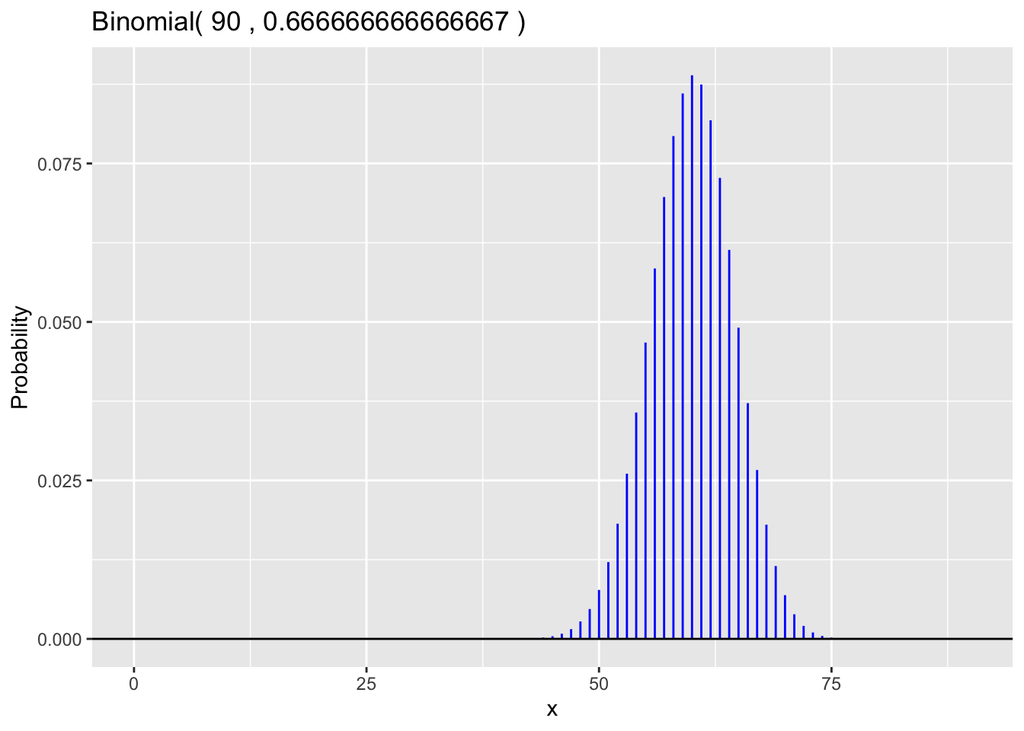

```r
n <- 90
p <- 2/3
gbinom(n, p)
```

Once we observe a value for $x$, we can consider $P(X = x)$ to be a function of the parameter $p$ instead of as a function of $x$. This new function is referred to as a *likelihood function*.

$$L(p \mid X=x) = {n\choose x}p^x(1-p)^{n-x}$$

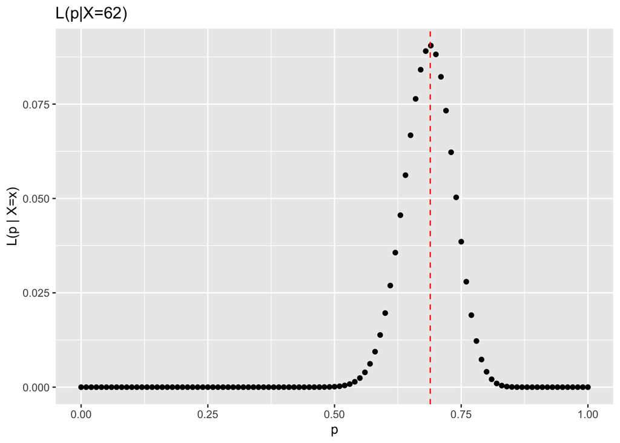

```r
set.seed(1234)
n <- 90
x <- rbinom(1,n,p=2/3) # generate an observed x

df <- tibble(pseq=seq(0,1,by=.01), L=dbinom(x,n,pseq))

ggplot(df, aes(pseq, L)) +
  geom_point() +
  xlab("p") +
  ylab("L(p | X=x)") +
  ggtitle(paste0("L(p|X=",x,")")) +
  geom_vline(xintercept=x/n, color="red",linetype="dashed")
```

```r
## Run this code a few more times (avoiding the set.seed)
```

The likelihood function gives us “likely” values of $p$ given the observed data.  
Notice that the maximum value of the likelihood is at our $\hat{p} = \frac{x}{90}$.

It turns out the *maximum likelihood estimate* for a binomial distribution is our $\hat{p} = \frac{x}{n}$.

Likelihood functions are commonly used in statistics, and they will come up again later this semester.